# Hungarian Chickenpox Analysis

In this notebook there will be an analysis of Hungarian weekly chickenpox cases. First, let’s have a look at the data.

# EDA

```r
# Load data
data = read.csv('hungary_chickenpox.csv')
print(paste('data is a', class(data)))
```

```
[1] "data is a data.frame"
```

```r
print(data)
```

| Date | BUDAPEST | BARANYA | BACS | BEKES | BORSOD | CSONGRAD | FEJER | GYOR | HAJDU | HEVES | JASZ | KOMAROM | NOGRAD | PEST | SOMOGY | SZABOLCS | TOLNA | VAS | VESZPREM | ZALA |
| --- | --- | --- | --- | --- | --- | --- | --- | --- | --- | --- | --- | --- | --- | --- | --- | --- | --- | --- | --- | --- |
| 03/01/2005 | 168 | 79 | 30 | 173 | 169 | 42 | 136 | 120 | 162 | 36 | 130 | 57 | 2 | 178 | 66 | 64 | 11 | 29 | 87 | 68 |
| 10/01/2005 | 157 | 60 | 30 | 92 | 200 | 53 | 51 | 70 | 84 | 28 | 80 | 50 | 29 | 141 | 48 | 29 | 58 | 53 | 68 | 26 |
| 17/01/2005 | 96 | 44 | 31 | 86 | 93 | 30 | 93 | 84 | 191 | 51 | 64 | 46 | 4 | 157 | 33 | 33 | 24 | 18 | 62 | 44 |
| 24/01/2005 | 163 | 49 | 43 | 126 | 46 | 39 | 52 | 114 | 107 | 42 | 63 | 54 | 14 | 107 | 66 | 50 | 25 | 21 | 43 | 31 |
| 31/01/2005 | 122 | 78 | 53 | 87 | 103 | 34 | 95 | 131 | 172 | 40 | 61 | 49 | 11 | 124 | 63 | 56 | 7 | 47 | 85 | 60 |
| 07/02/2005 | 174 | 76 | 77 | 152 | 189 | 26 | 74 | 181 | 157 | 44 | 95 | 97 | 26 | 146 | 59 | 54 | 27 | 54 | 48 | 60 |
| 14/02/2005 | 153 | 103 | 54 | 192 | 148 | 65 | 100 | 118 | 129 | 40 | 88 | 56 | 10 | 119 | 104 | 85 | 20 | 32 | 153 | 70 |
| 21/02/2005 | 115 | 74 | 64 | 174 | 140 | 56 | 111 | 175 | 138 | 60 | 112 | 70 | 21 | 178 | 70 | 75 | 5 | 66 | 149 | 54 |
| 28/02/2005 | 119 | 86 | 57 | 171 | 90 | 65 | 118 | 105 | 194 | 60 | 67 | 46 | 12 | 112 | 116 | 76 | 22 | 45 | 102 | 42 |
| 07/03/2005 | 114 | 81 | 129 | 217 | 167 | 64 | 93 | 154 | 119 | 34 | 118 | 73 | 6 | 130 | 68 | 59 | 31 | 85 | 96 | 54 |

[output cut: 512 more lines]

Is possible to see how the dataset contains 522 rows (weeks) and 21 columns (1 for the date and 20 cities). Now we must convert the first column in the proper format and transform the dataset in a multivariate time series.

```r
data$Date <- as.Date(data$Date, format='%d/%m/%Y')
print(str(data))
```

```
'data.frame':   522 obs. of  21 variables:
 $ Date    : Date, format: "2005-01-03" "2005-01-10" ...
 $ BUDAPEST: int  168 157 96 163 122 174 153 115 119 114 ...
 $ BARANYA : int  79 60 44 49 78 76 103 74 86 81 ...
 $ BACS    : int  30 30 31 43 53 77 54 64 57 129 ...
 $ BEKES   : int  173 92 86 126 87 152 192 174 171 217 ...
 $ BORSOD  : int  169 200 93 46 103 189 148 140 90 167 ...
 $ CSONGRAD: int  42 53 30 39 34 26 65 56 65 64 ...
 $ FEJER   : int  136 51 93 52 95 74 100 111 118 93 ...
 $ GYOR    : int  120 70 84 114 131 181 118 175 105 154 ...
 $ HAJDU   : int  162 84 191 107 172 157 129 138 194 119 ...
 $ HEVES   : int  36 28 51 42 40 44 40 60 60 34 ...
 $ JASZ    : int  130 80 64 63 61 95 88 112 67 118 ...
 $ KOMAROM : int  57 50 46 54 49 97 56 70 46 73 ...
 $ NOGRAD  : int  2 29 4 14 11 26 10 21 12 6 ...
 $ PEST    : int  178 141 157 107 124 146 119 178 112 130 ...
 $ SOMOGY  : int  66 48 33 66 63 59 104 70 116 68 ...
 $ SZABOLCS: int  64 29 33 50 56 54 85 75 76 59 ...
 $ TOLNA   : int  11 58 24 25 7 27 20 5 22 31 ...
 $ VAS     : int  29 53 18 21 47 54 32 66 45 85 ...
 $ VESZPREM: int  87 68 62 43 85 48 153 149 102 96 ...
 $ ZALA    : int  68 26 44 31 60 60 70 54 42 54 ...
NULL
```

Now, we need to convert the dataset in to a timeseries. We will use the library “zoo”.

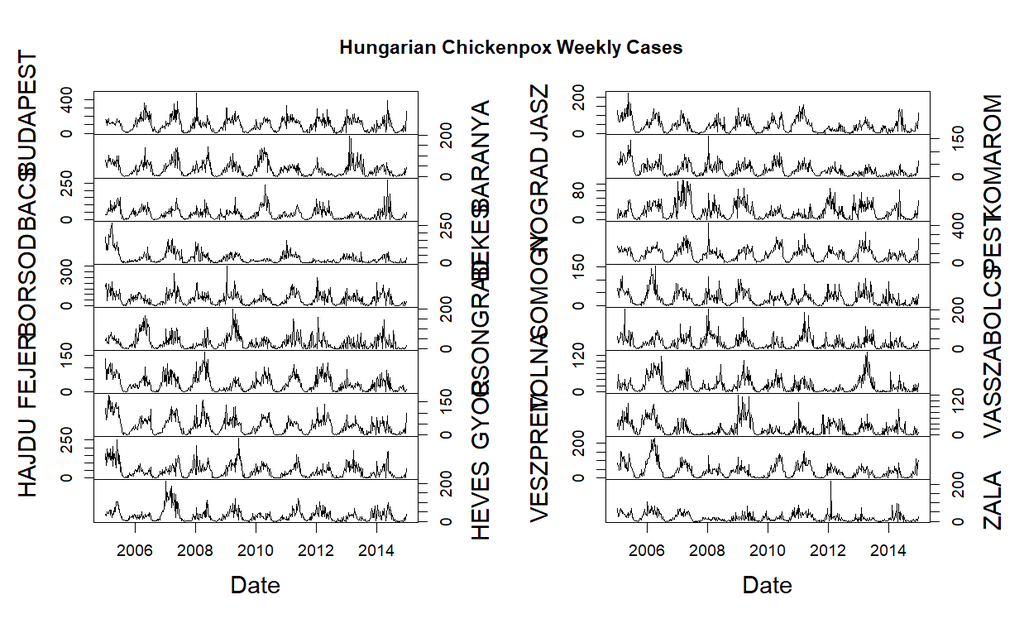

```r
library(zoo)
zoo_data <- zoo(data[2:ncol(data)], order.by=data$Date)
#print(str(zoo_data))
plot.zoo(zoo_data, plot.type='multiple', nc=2, xlab = 'Date',
         main='Hungarian Chickenpox Weekly Cases', yax.flip = TRUE)
```

A seasonal behavior is clear in every city (county). It seems also that the peaks coincide. Let’s check. For a better comparison, let’s scale the data in order to eliminate differences in population between cities.

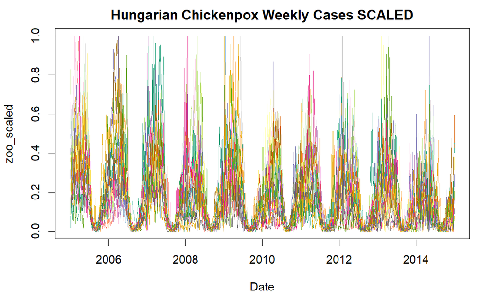

```r
# To have 20 different colors
library(RColorBrewer)
colors <- c(brewer.pal(n=12, name='Set3'), brewer.pal(n=8, name='Dark2'))
# Create a function to scale each column between 0 and 1
min_max_scaler <- function(x){
  (x - min(x)) / (max(x) - min(x))
}
data_scaled <- as.data.frame(lapply(data[, -1], min_max_scaler))
zoo_scaled <- zoo(x = data_scaled, order.by=data$Date)
plot.zoo(zoo_scaled, plot.type='single', xlab = 'Date',
         main='Hungarian Chickenpox Weekly Cases SCALED', col=colors)
```

Let’s now compute the correlation matrix.

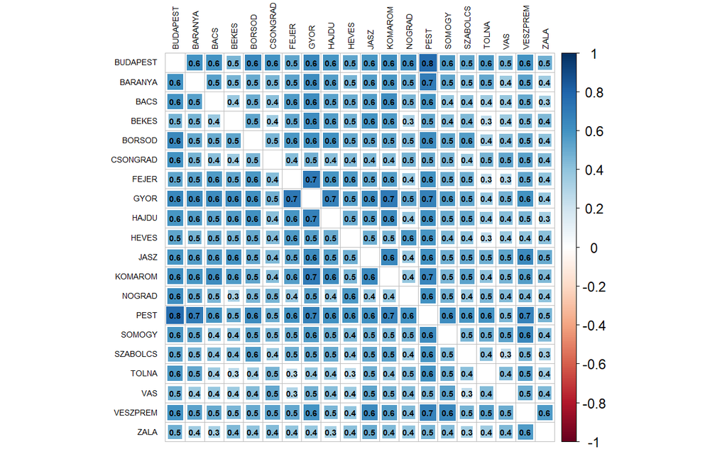

```r
corr_matrix <- cor(zoo_data, method = 'pearson')
library(corrplot)
corrplot(corr_matrix, method = 'square', type='full', addCoef.col = 'black',
         number.cex = 0.5, diag = FALSE, number.digits = 1, tl.cex=0.5, tl.col = 'black')
```

```r
print(paste('Minimum correlation value is:', min(corr_matrix)))
```

```
[1] "Minimum correlation value is: 0.258397260790711"
```

Now, Let’s focus on the country aggregate.

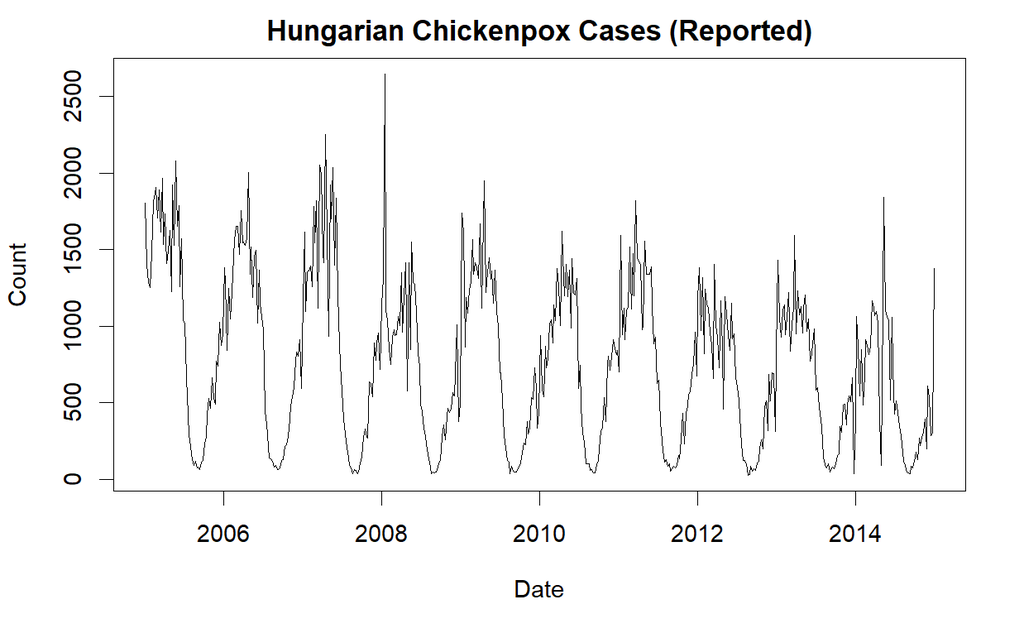

```r
total_cases <- rowSums(data[, -1])
total_cases <- zoo(total_cases, order.by = data$Date)
plot.zoo(total_cases, main = 'Hungarian Chickenpox Cases (Reported)',
         ylab = 'Count', xlab = 'Date')
```

It is clear a seasonal pattern (more cases in cold months?) and is also possible to notice that peaks’ height is decreasing. To reduce oscillations, a monthly aggregation is now performed. There will be used a “sum” aggregation function as dataset refers to reported cases and not active cases.

```r
monthly_data <- aggregate(zoo_data, as.yearmon, sum)
monthly_total <- aggregate(total_cases, as.yearmon, sum)
total_ts <- ts(monthly_total, start = c(2005, 1), freq=12)
print(total_ts)
```

```
      Jan  Feb  Mar  Apr  May  Jun  Jul  Aug  Sep  Oct  Nov  Dec
2005 7231 7267 7009 6258 8411 5662 2388  629  381 1928 2458 3591
2006 5810 5893 6428 6651 6998 4599 2139  424  324 1145 2390 3140
2007 6600 5980 6982 7678 7063 4671 1615  268  251 1287 2692 4488
2008 6102 3509 5303 4150 5099 4426 1248  331  391 1299 1932 3267
2009 5408 5176 7123 5706 5466 5304 1708  411  244  746 2070 2090
2010 2936 3579 5708 5283 6400 4327 1753  427  306 1383 3447 3419
2011 5274 4869 5944 4807 6968 3572 1521  480  318 1214 2040 3077
2012 5674 4461 3946 4147 4053 3679 1785  280  271  888 1993 3043
2013 4522 4366 4564 5344 4341 3460 2379  417  365  974 1824 2140
2014 3320 2954 5034 2587 5148 3773 1580  492  355  794 1172 3104
```

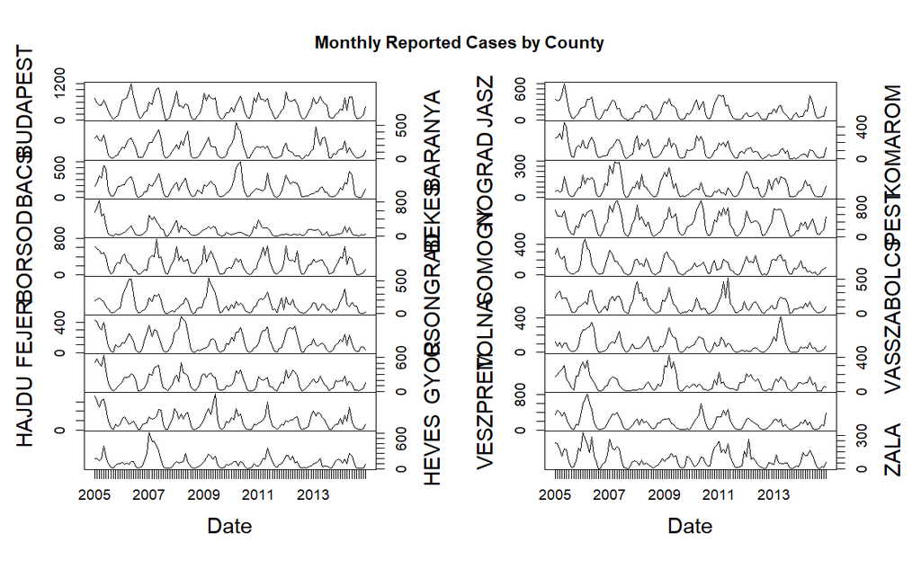

```r
plot(monthly_data, yax.flip = TRUE, main = 'Monthly Reported Cases by County', xlab = 'Date')
```

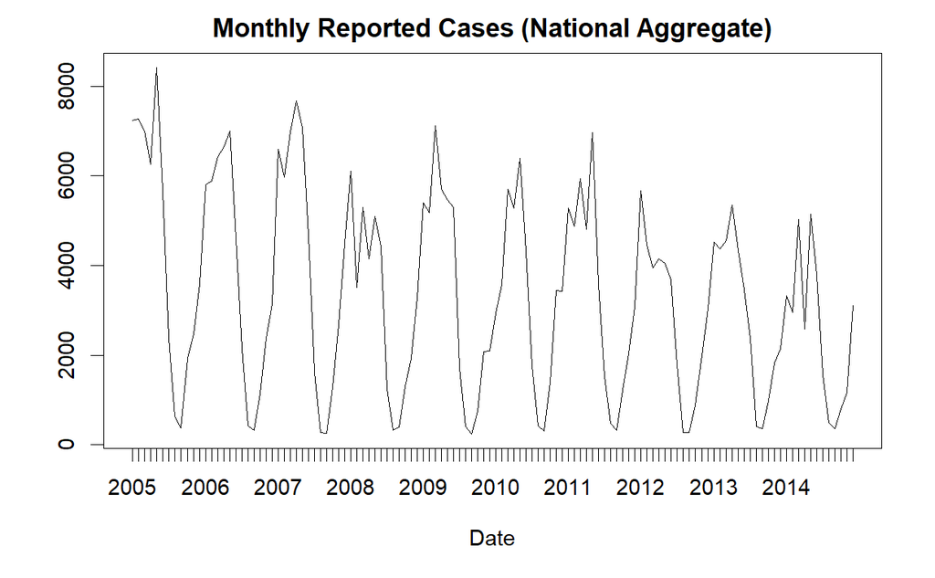

```r
plot(monthly_total, main = 'Monthly Reported Cases (National Aggregate)', ylab = '', xlab = 'Date')
```

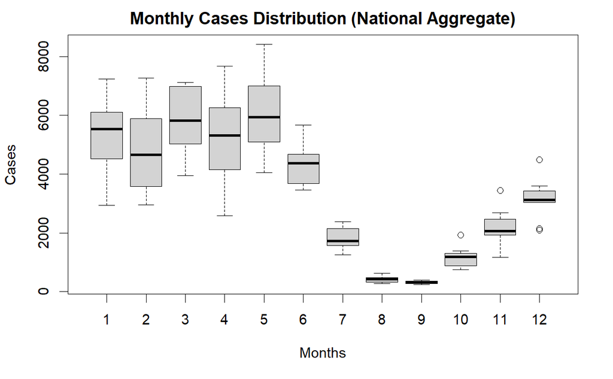

```r
boxplot(total_ts ~ cycle(total_ts), xlab = 'Months', ylab = 'Cases',
        main='Monthly Cases Distribution (National Aggregate)')
```

As expected, the number of reported cases is higher in cold months that are also months in which schools are open and virus can spread easily.

# Decomposition

First, we will try with the additive method.

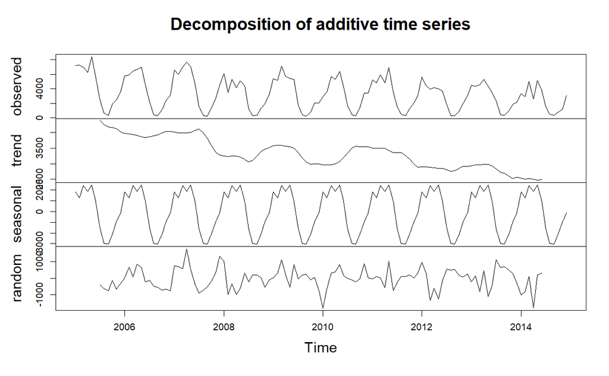

```r
cases_decompose <- decompose(total_ts)
plot(cases_decompose)
par(mar = c(5, 4, 6, 2))
```

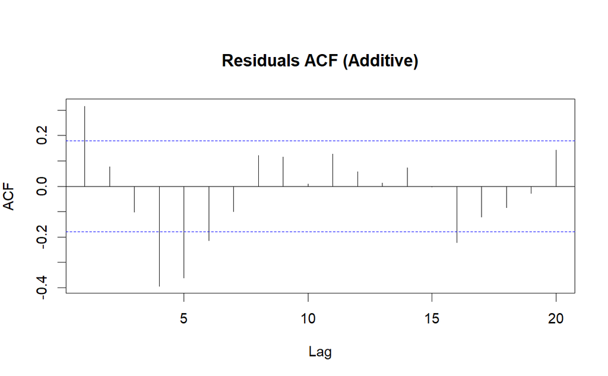

```r
plot(acf(c(cases_decompose$random), na.action = na.pass, plot = FALSE),
     main = 'Residuals ACF (Additive)')
```

The downward trend is clear. Is remarkable that the random component’s volatility is lower when cases are low; this suggest to use the multiplicative decomposition. We see also a significant autocorrelation when the lag is 4 and 5.

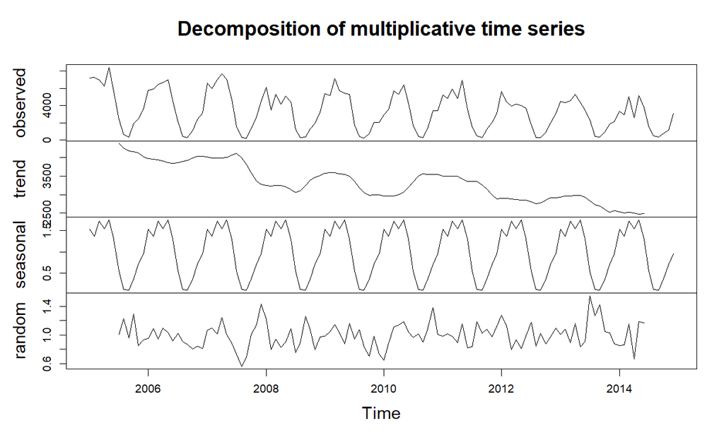

```r
cases_decompose <- decompose(total_ts, type = 'multiplicative')
plot(cases_decompose)
par(mar = c(5, 4, 6, 2))
```

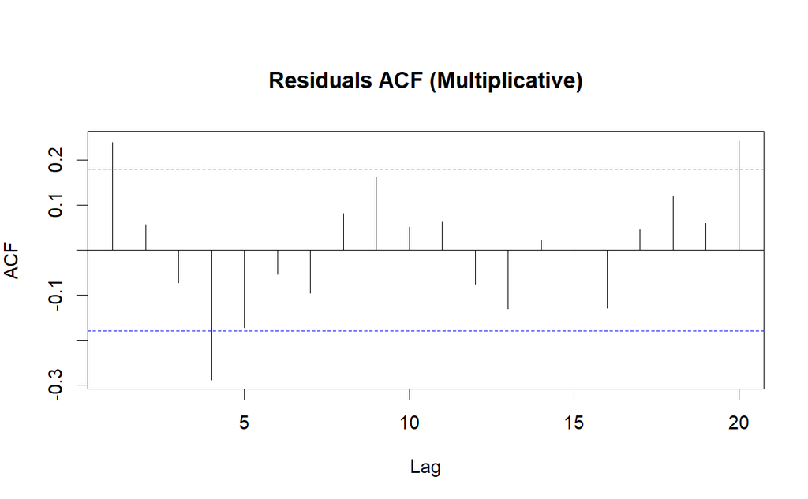

```r
plot(acf(c(cases_decompose$random), na.action = na.pass, plot = FALSE),
     main = 'Residuals ACF (Multiplicative)')
```

With the multiplicative approach, the volatility of the random component is more constant and the autocorrelation in the random component is less significant (but we still have a significant autocorrelation with lag = 4).

# Forecasting

In this notebook we wont use the train-test split (we will use it in the Python notebook). We will compare the models using the fitted data on the training data. We will forecast values to years forward (24 months, 104 weeks). ## Holt-Winters Forecast

```r
library(forecast)
# Fit additive and multiplicative models
hw_monthly_mul <- hw(monthly_total, seasonal='multiplicative')
hw_monthly_add <- hw(monthly_total, seasonal='additive')
# Compute sum of squared residuals
ssr_mul <- sum((hw_monthly_mul$fitted - hw_monthly_mul$x)^2)
ssr_add <- sum((hw_monthly_add$fitted - hw_monthly_add$x)^2)
print(paste('SSR multiplicative: ', ssr_mul))
```

```
[1] "SSR multiplicative:  51094528.7479929"
```

```r
print(paste('SSR additive: ', ssr_add))
```

```
[1] "SSR additive:  59655353.6817714"
```

```r
# Keep the best model according to SSR (multiplicative model)
# Compute 24 months forecast horizon
forecast_hw <- forecast(hw_monthly_mul, h=24)
plot(forecast_hw)
lines(hw_monthly_mul$fitted, col='blue')
```

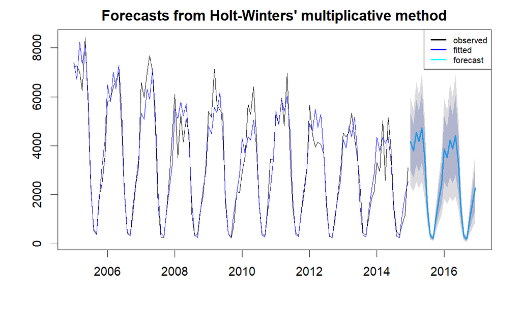

```r
legend('topright', legend = c('observed', 'fitted', 'forecast'), col = c('black', 'blue', 'cyan'), lwd = 2, cex = 0.7)
```

```r
print(paste('Root mean squared error on fitted values: ', sqrt(ssr_mul / length(hw_monthly_mul$residuals))))
```

```
[1] "Root mean squared error on fitted values:  652.524129489943"
```

## ARIMA Forecast

```r
# Use auto.arima function
arima_model <- auto.arima(total_ts)
# Compute sum of squared residuals
ssr_arima <- sum((arima_model$fitted - arima_model$x)^2)
print(paste('SSR arima: ', ssr_arima))
```

```
[1] "SSR arima:  58344696.0481144"
```

```r
print(paste('Root mean squared error on fitted values: ', sqrt(ssr_arima / length(arima_model$residuals))))
```

```
[1] "Root mean squared error on fitted values:  697.284590680845"
```

```r
print(arima_model)
```

```
Series: total_ts
ARIMA(1,0,0)(0,1,1)[12] with drift

Coefficients:
         ar1     sma1     drift
      0.3993  -0.7718  -15.1894
s.e.  0.0937   0.1168    3.6447

sigma^2 = 555664:  log likelihood = -871.52
AIC=1751.04   AICc=1751.42   BIC=1761.76
```

```r
forecast_arima <- forecast(arima_model, h=24)
plot(forecast_arima, main = 'Monthly Reported Cases ARIMA', ylab = 'Cases', xlab = 'Date')
points(forecast_arima$fitted, col='blue', type='l', lty=2)
```

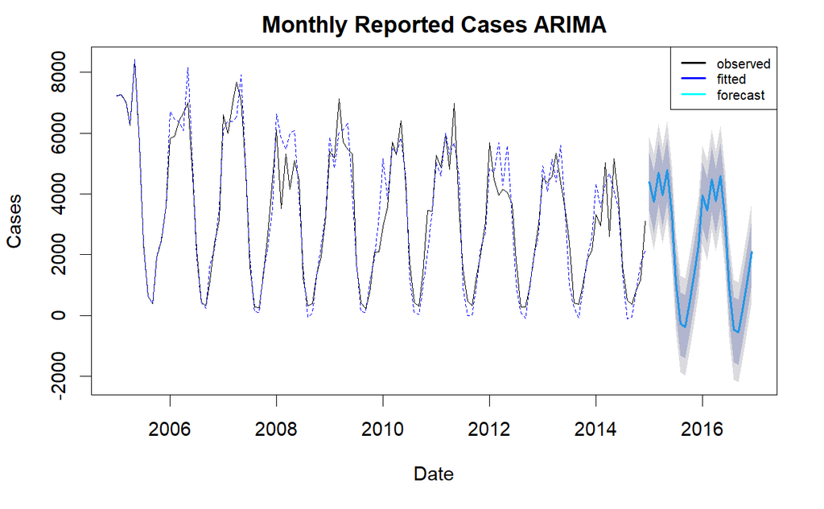

```r
legend('topright', legend = c('observed', 'fitted', 'forecast'), col = c('black', 'blue', 'cyan'), lwd = 2, cex = 0.7)
```

# Plot arima and HW predictions in the same plot

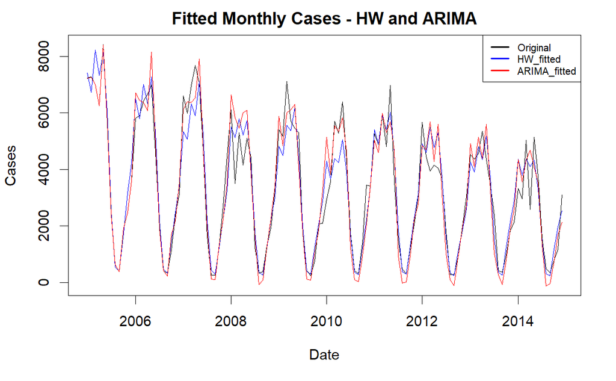

```r
fitted_df <- cbind(total_ts, hw_monthly_mul$fitted, arima_model$fitted)
colnames(fitted_df) <- c('Original', 'HW_fitted', 'ARIMA_fitted')
plot(fitted_df, plot.type = 'single', col = c('black', 'blue', 'red'),
     main='Fitted Monthly Cases - HW and ARIMA', ylab = 'Cases', xlab = 'Date')
legend('topright', legend = c('Original', 'HW_fitted', 'ARIMA_fitted'), col = c('black', 'blue', 'red'), lwd = 2, cex = 0.7)
```

# Plot forecasts in the same plot

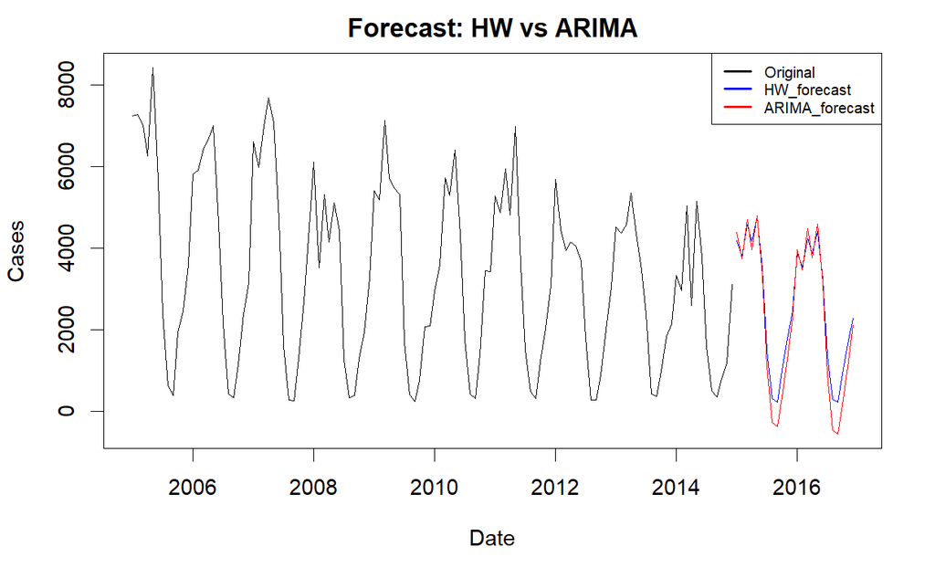

```r
forecast_df <- matrix(nrow=(length(total_ts) + length(forecast_arima$mean)), ncol=3)
forecast_df[1:length(total_ts), 1] <- total_ts
forecast_df[(length(total_ts)+1): nrow(forecast_df), 2] <- as.numeric(forecast_hw$mean)
forecast_df[(length(total_ts)+1): nrow(forecast_df), 3] <- forecast_arima$mean
colnames(forecast_df) <- c('Original', 'Forecast HW', 'Forecast ARIMA')
forecast_df <- ts(forecast_df, start = c(2005, 1), freq=12 )
plot(forecast_df, plot.type='single', col=c('black', 'blue', 'red'),
     main = 'Forecast: HW vs ARIMA', ylab = 'Cases', xlab = 'Date')
legend('topright', legend = c('Original', 'HW_forecast', 'ARIMA_forecast'), col = c('black', 'blue', 'red'), lwd = 2, cex = 0.7)
```

# Model Evaluation

First, we create some functions to evaluate models.

```r
# Create functions to compute metrics
mse <- function(y_true, y_pred){
  return(mean((y_pred - y_true)^2))
}
me <- function(y_true, y_pred){
  return(mean(y_pred - y_true))
}
mad <- function(y_true, y_pred){
  return(mean(abs(y_pred - y_true)))
}
rmse <- function(y_true, y_pred){
  return(sqrt(mean((y_pred - y_true)^2)))
}
mape <- function(y_true, y_pred){
  return(mean(abs((y_pred - y_true) / y_true)))
}

mpe <- function(y_true, y_pred){
  return(mean((y_pred - y_true) / y_true))
}

compute_metrics <- function(x, y){
  return(c(mse(x, y), me(x, y), mad(x, y), rmse(x, y), mape(x, y), mpe(x, y)))
}
hw_mul_metrics <- compute_metrics(total_ts, hw_monthly_mul$fitted)
hw_add_metrics <- compute_metrics(total_ts, hw_monthly_add$fitted)
arima_metrics <- compute_metrics(total_ts, arima_model$fitted)
metric_name <- c('MSE', 'ME', 'MAD', 'RMSE', 'MAPE', 'MPE')

metrics_df <- as.data.frame(cbind(hw_mul_metrics, hw_add_metrics, arima_metrics))
metrics_df <- format(round(metrics_df, 2), scientific=FALSE)
row.names(metrics_df) <- metric_name
print(metrics_df)
```

|  | hw_mul_metrics | hw_add_metrics | arima_metrics |
| --- | --- | --- | --- |
| MSE | 425787.74 | 497127.95 | 486205.80 |
| ME | 28.12 | -21.06 | 20.12 |
| MAD | 483.69 | 553.64 | 491.07 |
| RMSE | 652.52 | 705.07 | 697.28 |
| MAPE | 0.17 | 0.29 | 0.26 |
| MPE | 0.04 | 0.01 | -0.10 |

Looking at the metrics, it seems that the best model is the Holt-Winters with a multiplicative approach. This is also confirmed by looking at the plots If we look at the ME and MPE we see how HW-additive performs better, this means that predictions are ‘more centered’ than the HW-multiplicative one. Looking at the ME, HW-multiplicative tends to over estimate the predictions, on the other hand, HW-additive tends to under estimate predictions. # Check for normality of residuals

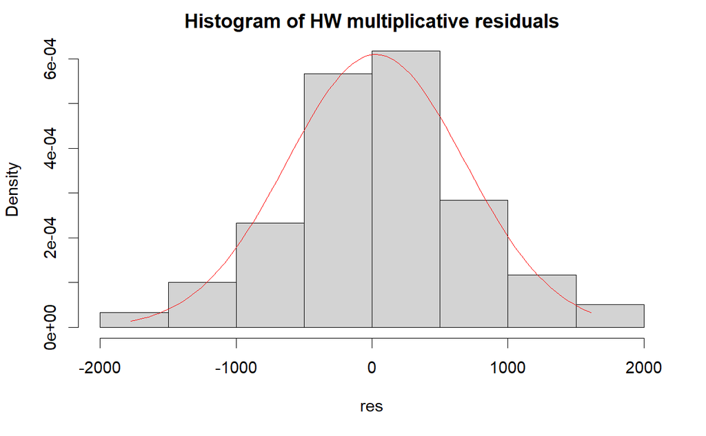

```r
hw_mul_res <- hw_monthly_mul$fitted - total_ts
hw_add_res <- hw_monthly_add$fitted - total_ts
arima_res <- arima_model$fitted - total_ts

# Histograms and QQ-plot

# HW multiplicative
res <- hw_mul_res
hist(res, prob=TRUE, main = 'Histogram of HW multiplicative residuals')
# Add gaussian line to plot
mu <- mean(res)
sigma <- sd(res)
x <- seq(min(res), max(res), length=80)
y <- dnorm(x, mu, sigma)
# Add line
lines(x, y, col='red')
```

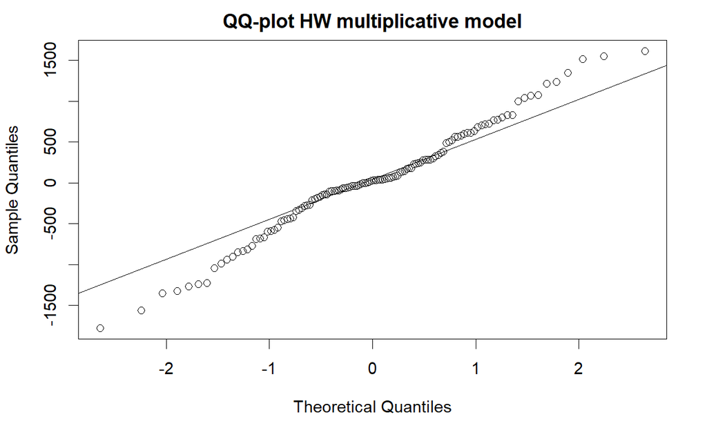

```r
qqnorm(res, main = 'QQ-plot HW multiplicative model')
qqline(res)
```

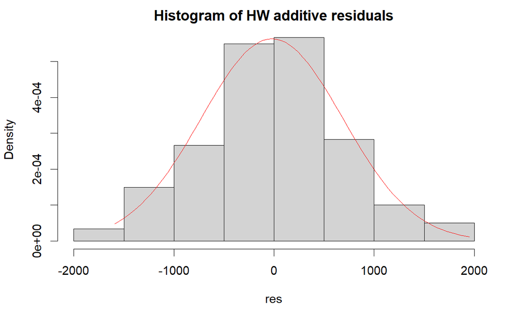

```r
# HW additive
res <- hw_add_res
hist(res, prob=TRUE, main = 'Histogram of HW additive residuals')
# Add gaussian line to plot
mu <- mean(res)
sigma <- sd(res)
x <- seq(min(res), max(res), length=80)
y <- dnorm(x, mu, sigma)
# Add line
lines(x, y, col='red')
```

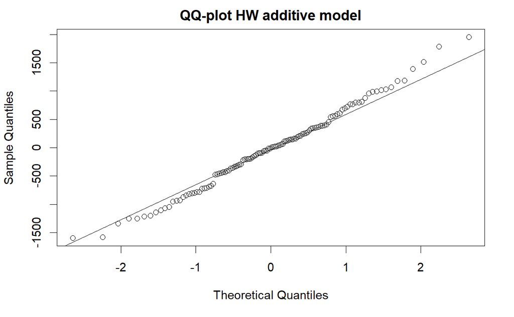

```r
qqnorm(res, main = 'QQ-plot HW additive model')
qqline(res)
```

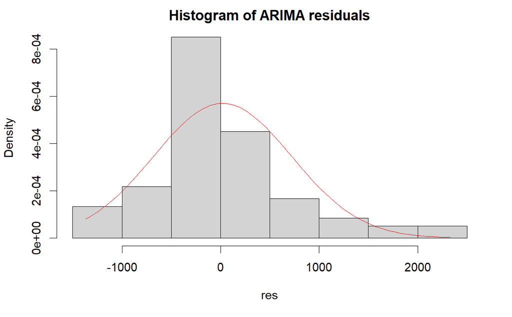

```r
# ARIMA
res <- arima_res
hist(res, prob=TRUE, main = 'Histogram of ARIMA residuals')
# Add gaussian line to plot
mu <- mean(res)
sigma <- sd(res)
x <- seq(min(res), max(res), length=80)
y <- dnorm(x, mu, sigma)
# Add line
lines(x, y, col='red')
```

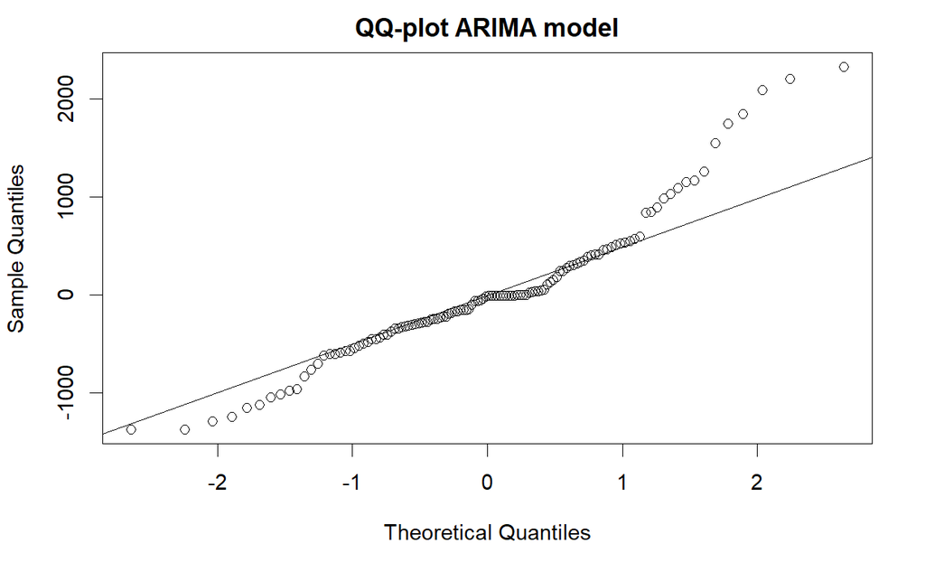

```r
qqnorm(res, main = 'QQ-plot ARIMA model')
qqline(res)
```

```r
# Jarque-brera normality test
library(tseries)
print(paste('p-value for multiplicative HW:', jarque.bera.test(hw_mul_res)$p.value))
```

```
[1] "p-value for multiplicative HW: 0.707999354299451"
```

```r
print(paste('p-value for additive HW:', jarque.bera.test(hw_add_res)$p.value))
```

```
[1] "p-value for additive HW: 0.795896931283891"
```

```r
print(paste('p-value for ARIMA:', jarque.bera.test(arima_res)$p.value))
```

```
[1] "p-value for ARIMA: 4.38361893118078e-07"
```

With ARIMA model, residuals on fitted values are not normally distributed (p-value of Jarque-Brera test is less than 5%). This is confermed also by looking at the historams and QQ-plots.

# Time Frequency Analysis

For this analysis we wil use the weekly data.

```r
# First, I need to check for stationarity
print(adf.test(total_cases))
```

```
Avvertimento: p-value smaller than printed p-value
```

```
    Augmented Dickey-Fuller Test

data:  total_cases
Dickey-Fuller = -6.3754, Lag order = 8, p-value = 0.01
alternative hypothesis: stationary
```

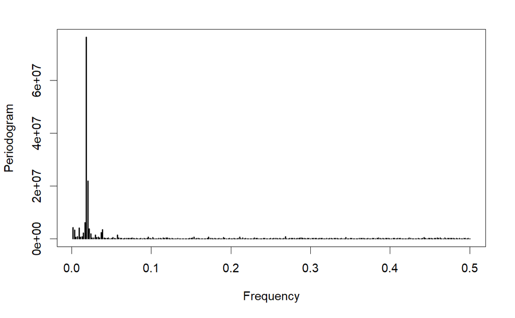

```r
# p-value is low; I can Reject the null. Data is stationary
# Create periodogram
library(TSA)
PGram <- periodogram(total_cases)
```

```r
# From the periodogram we see two major peaks and some other minor peaks
PGramAsDataFrame <- data.frame(freq=PGram$freq, spec=PGram$spec)
order <- PGramAsDataFrame[order(-PGramAsDataFrame$spec),]
print(order)
```

|  | freq | spec |
| --- | --- | --- |
| 10 | 0.018518519 | 7.633485e+07 |
| 11 | 0.020370370 | 2.179903e+07 |
| 9 | 0.016666667 | 6.116935e+06 |
| 1 | 0.001851852 | 4.183379e+06 |
| 5 | 0.009259259 | 4.120063e+06 |
| 12 | 0.022222222 | 3.811656e+06 |
| 21 | 0.038888889 | 3.469754e+06 |
| 2 | 0.003703704 | 3.244075e+06 |
| 20 | 0.037037037 | 2.317630e+06 |
| 8 | 0.014814815 | 2.122056e+06 |

[output cut: 260 more lines]

```r
top2 <- head(order, 2)
print(top2)
```

|  | freq | spec |
| --- | --- | --- |
| 10 | 0.01851852 | 76334850 |
| 11 | 0.02037037 | 21799032 |

```r
TimePeriod <- 1/top2[2, 1]
TimePeriod2 <- 1/top2[1, 1]
print(TimePeriod)
```

```
[1] 49.09091
```

```r
print(TimePeriod2)
```

```
[1] 54
```

We see how the time frequencies corresponds to 49 and 54, very similar to 52 wich is the number of weeks in the a year. Let’s try to do it with the monthly data

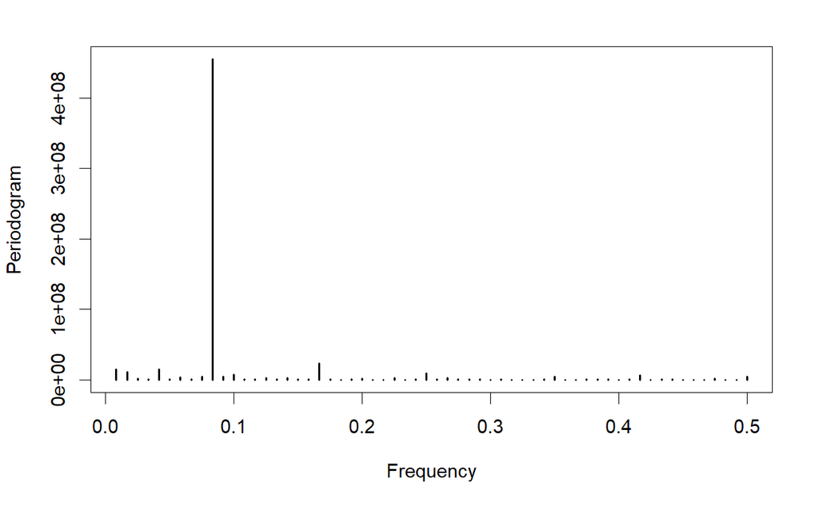

```r
# Let's try to do it with the monthly data
PGram <- periodogram(total_ts)
```

```r
# From the periodogram we see a major peak
PGramAsDataFrame <- data.frame(freq=PGram$freq, spec=PGram$spec)
order <- PGramAsDataFrame[order(-PGramAsDataFrame$spec),]
print(order)
```

|  | freq | spec |
| --- | --- | --- |
| 10 | 0.083333333 | 454871470.03 |
| 20 | 0.166666667 | 23506998.62 |
| 5 | 0.041666667 | 14602191.17 |
| 1 | 0.008333333 | 14435481.14 |
| 2 | 0.016666667 | 10877169.47 |
| 30 | 0.250000000 | 9091402.68 |
| 12 | 0.100000000 | 7043710.12 |
| 50 | 0.416666667 | 6261208.14 |
| 11 | 0.091666667 | 4503080.67 |
| 9 | 0.075000000 | 4397664.85 |

[output cut: 50 more lines]

```r
top1 <- head(order, 1)
print(top2)
```

|  | freq | spec |
| --- | --- | --- |
| 10 | 0.01851852 | 76334850 |
| 11 | 0.02037037 | 21799032 |

```r
TimePeriod <- 1/top2[1, 1]
print(TimePeriod)
```

```
[1] 54
```

# GARCH

```r
garch_model <- garch(total_cases)
```

[output not shown]

```r
summary(garch_model)
```

```
Call:
garch(x = total_cases)

Model:
GARCH(1,1)

Residuals:
    Min      1Q  Median      3Q     Max
0.04581 0.43222 0.75146 0.95777 2.46257

Coefficient(s):
    Estimate  Std. Error  t value Pr(>|t|)
a0 2.666e+05   7.554e+04    3.529 0.000417 ***
a1 9.534e-01   3.516e-01    2.711 0.006701 **
b1 1.303e-09   2.023e-01    0.000 1.000000
---
Signif. codes:  0 ‘***’ 0.001 ‘**’ 0.01 ‘*’ 0.05 ‘.’ 0.1 ‘ ’ 1

Diagnostic Tests:
    Jarque Bera Test

data:  Residuals
X-squared = 40.323, df = 2, p-value = 1.753e-09


    Box-Ljung test

data:  Squared.Residuals
X-squared = 15.925, df = 1, p-value = 6.59e-05
```